# Evolución del COVID-19 en la provincia de Granada

Wenceslao Arroyo Machado

Actualizado el 21 de abril de 2020

# 1 Introducción

El objetivo de esta notebook es visualizar los datos disponibles de la incidencia del COVID-19 en la provincia de Granada. Cabe destacar que por este motivo no se pretende realizar un análisis de los mismos sino ofrecer gráficos complementarios a los disponibles en el informe diario oficial a modo de fotografía de la situación actual.

# 2 Metodología

Los materiales empleados proceden de la [Junta de Andalucía](https://www.juntadeandalucia.es/organismos/saludyfamilias/areas/salud-vida/paginas/Nuevo_Coronavirus.html), los cuales son actualizados a diario. A excepción de los casos nuevos, el resto de variables (fallecimientos, curados, hospitalizados e ingresos en UCI) aparecen recogidos como valores acumulados, por lo que estos casos han requerido ser disgregados. No obstante, en los valores obtenidos de curados y hospitalizados diarios exite un día que dicha diferencia de acumulados da como resultado un valor negativo.

```r
datos <- read.csv2('datos.csv', stringsAsFactors = FALSE)
datos$Fecha <- as.Date(datos$Fecha, format = '%d/%m/%Y')

edad <- read.csv2('datos_edad.csv', stringsAsFactors = FALSE, encoding = 'UTF-8')
#edad <- edad[-which(edad$Edad == 'TOTAL' | edad$Sexo == 'Ambos sexos'),]
edad$Valor <- 100*edad$Valor/sum(edad$Valor)
```

Partiendo de las medidas antes citadas se han realizados gráficos con la evolución diaria y acumulada, incluyendo en ambos la media móvil de 3 días, la ratio de crecimiento cada 4 días y la de curados con el resto de medidas. Todos ellos se han realizado tomando como punto de inicio el día 12 de marzo, cuando se confirmaron los primeros positivos en la provincia. Tanto para la disgregación como para la visualización, elaborada mediante `ggplot2`, se han creado las funciones están incluidas a continuación. Al respecto cabe destacar que tanto los datos usados como este archivo *Rmd* se encuentran disponibles en [GitHub](https://github.com/Wences91/granada_covid-19).

```r
# función de disgregación
diario <- function(datos, columna){
  aux <- datos[which(datos$Medida == columna),]
  aux <- aux[order(aux$Fecha, decreasing = FALSE),]
  aux$Valor[-1] <- aux$Valor[-1] - aux$Valor[-dim(aux)[1]]

  return(aux)
}

# función para calcular la media movil de n días
media_movil <- function(datos, dias){
  datos$Valor <- filter(datos$Valor, rep(1/dias, dias), sides=2)

  return(datos)
}

# función para calcular la ratio de crecimiento en n días
ratio_crec <- function(datos, dias){
  datos$Valor_aux <- datos$Valor
  sapply(dias:dim(datos)[1], function(x){
    datos$Valor[x] <<- datos$Valor_aux[x] / datos$Valor_aux[x - (dias - 1)]
  })

  datos$Valor[which(datos$Valor == Inf)] <- NaN

  return(datos)
}

# función para dibujar la evolución diaria
evolucion <- function(datos, titulo, color){
  ggplot(datos, aes(x = Fecha, y = Valor)) +
    geom_col(fill = color) +
    geom_text(data = datos, aes(x = Fecha, y = Valor, label = round(Valor, 2)), size = 2, vjust = 0.5, hjust = -0.2, angle = 90) +
    geom_hline(yintercept = 1, alpha = 0.7) +
    scale_x_date(date_breaks = '2 days', date_labels = '%d-%b', limits = c(as.Date('11-03-2020', format = '%d-%m-%Y'), NA), expand = c(0,0)) +
    labs(title = titulo, x = '', y = '') +
    theme_minimal() +
    theme(axis.text.x = element_text(angle = 90, vjust = 0.5, hjust = 1),
          plot.title = element_text(hjust = 0.5))
}

# función para dibujar la evolución diaria y media móvil
evolucion_movil <- function(datos1, datos2, titulo, serie, color){
  ggplot() +
    geom_col(data=datos1, aes(x = Fecha, y = Valor, fill = serie)) +
    geom_line(data=datos2, aes(x = Fecha, y = Valor, color = 'Media móvil'), alpha = 0.7, size = 1.2) +
    geom_text(data = datos1, aes(x = Fecha, y = Valor, label = round(Valor, 2)), size = 2, vjust = 0.5, hjust = -0.2, angle = 90) +
    scale_fill_manual('', values = color) +
    scale_color_manual('', values = 'black') +
    scale_x_date(date_breaks = '2 days', date_labels = '%d-%b', limits = c(as.Date('11-03-2020', format = '%d-%m-%Y'), NA), expand = c(0,0)) +
    scale_y_continuous(expand = c(0, 0, 0.1, 0)) +
    labs(title = titulo, x = '', y = '') +
    theme_minimal() +
    theme(axis.text.x = element_text(angle = 90, vjust=0.5, hjust=1),
          plot.title = element_text(hjust = 0.5),
          legend.position = 'bottom')
}

ratios <- function(curados, datos, serie, color){
  aux <- curados
  aux$Valor <- (aux$Valor - datos$Valor)/(aux$Valor + datos$Valor)

  ggplot() +
    geom_col(data = aux, aes(x = Fecha, y = ifelse(Valor > 0, Valor, 0), fill = 'Curados')) +
    geom_col(data = aux, aes(x = Fecha, y = ifelse(Valor < 0, Valor, 0), fill = serie)) +
    geom_text(data = aux, aes(x = Fecha, y = Valor, label = round(Valor, 2), hjust = ifelse(Valor > 0, -0.2, 1.2)), vjust = 0.5, size = 2, angle = 90) +
    geom_hline(yintercept = 0, alpha = 0.7) +
    scale_fill_manual('', values =  setNames(c('#00A08A', color), c('Curados', serie))) +
    scale_x_date(date_breaks = '2 days', date_labels = '%d-%b', limits = c(as.Date('11-03-2020', format = '%d-%m-%Y'), NA), expand = c(0,0)) +
    scale_y_continuous(expand = c(0.1, 0, 0.1, 0)) +
    labs(title = paste0('Ratio Curados/',serie), x = '', y = '') +
    theme_minimal() +
    theme(axis.text.x = element_text(angle = 90, vjust=0.5, hjust=1),
          plot.title = element_text(hjust = 0.5),
          legend.position = 'bottom')
}
```

# 3 Visualización

## 3.1 Casos por edad y sexo

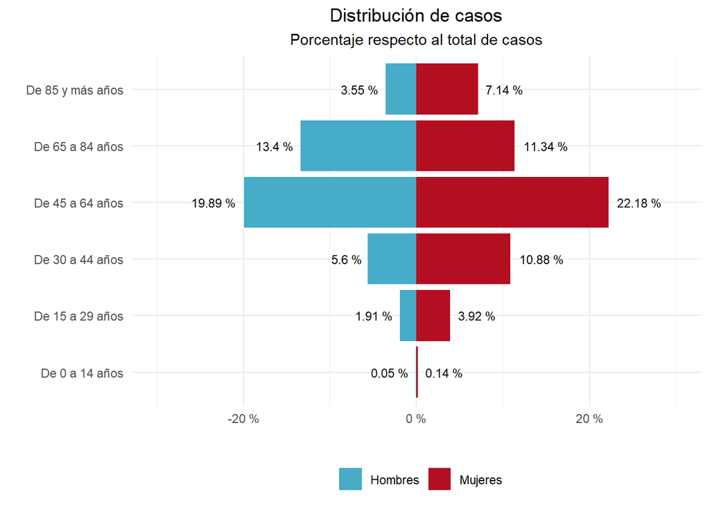

```r
ggplot(data=edad, aes(x = Edad, y = ifelse(Sexo == 'Hombres', -Valor, Valor), fill = Sexo)) +
  geom_bar(stat = "identity") +
  geom_text(data = edad, aes(x = Edad, y = ifelse(Sexo == 'Hombres', -Valor, Valor), label = paste(round(Valor, 2), '%'), vjust = 0.5, hjust = ifelse(Sexo == 'Hombres', 1.2, -0.2)), size = 3) +
  scale_fill_manual('', values = c('#46ACC8','#B40F20')) +
  scale_y_continuous(limits = c(-30, 30), labels = function(x) paste(x, '%')) +
  coord_flip() +
  labs(title = 'Distribución de casos', subtitle = 'Porcentaje respecto al total de casos', x = '', y = '') +
    theme_minimal() +
    theme(axis.text.x = element_text(vjust=1, hjust=0.5),
          plot.title = element_text(hjust = 0.5),
          plot.subtitle = element_text(hjust = 0.5),
          legend.position = 'bottom')
```

## 3.2 Evolución diaria

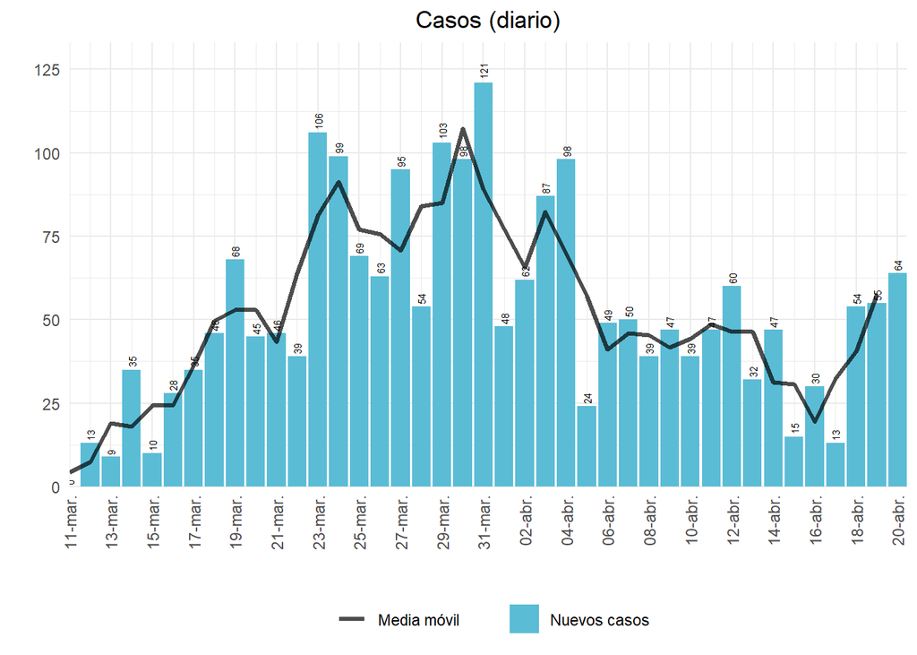

```r
#d_diarios <- datos[which(datos$Medida == 'Nuevos casos'),]
d_diarios <- diario(datos, 'Confirmados')

evolucion_movil(d_diarios, media_movil(d_diarios, 3), 'Casos (diario)', 'Nuevos casos', '#5BBCD6')
```

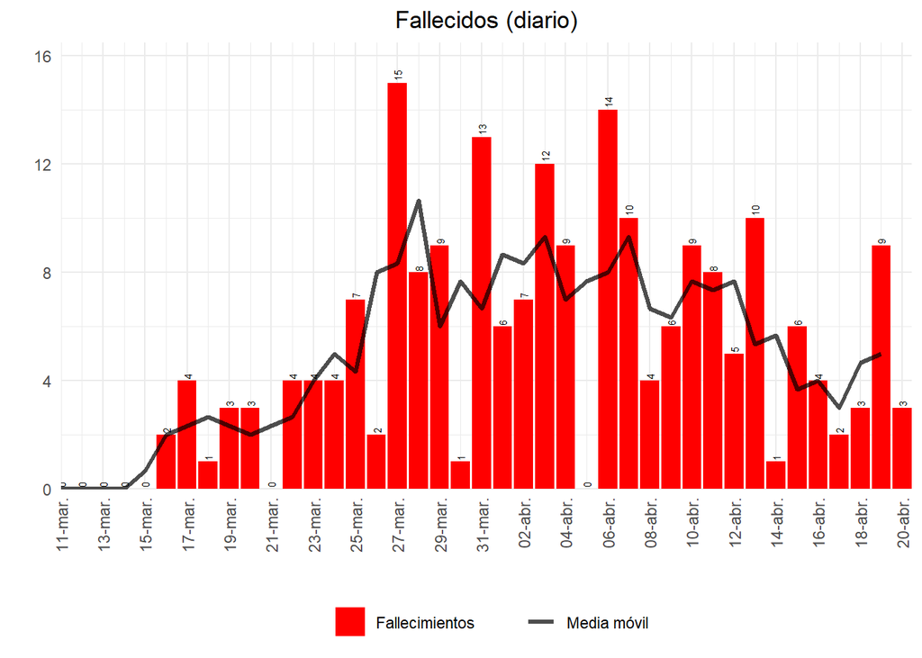

```r
f_diarios <- diario(datos, 'Fallecimientos')

evolucion_movil(f_diarios, media_movil(f_diarios, 3), 'Fallecidos (diario)', 'Fallecimientos', '#FF0000')
```

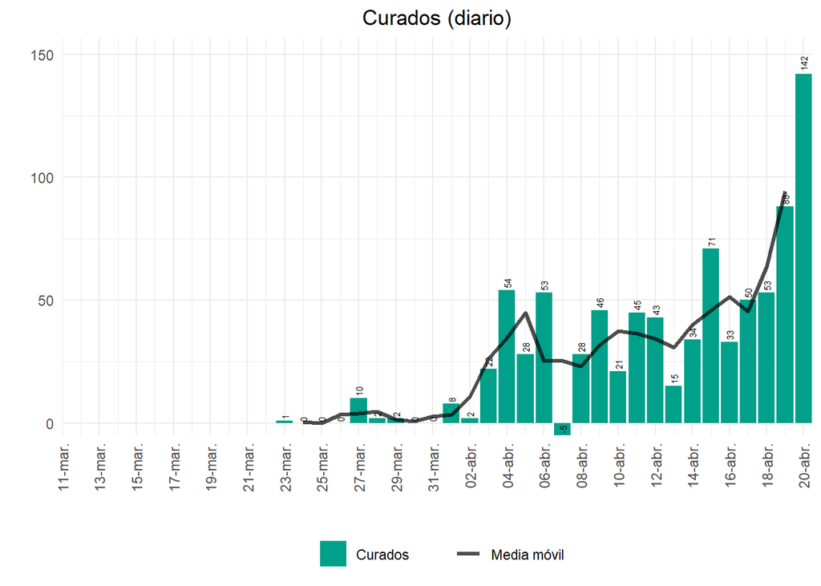

```r
c_diarios <- diario(datos, 'Curados')

evolucion_movil(c_diarios, media_movil(c_diarios, 3), 'Curados (diario)', 'Curados', '#00A08A')
```

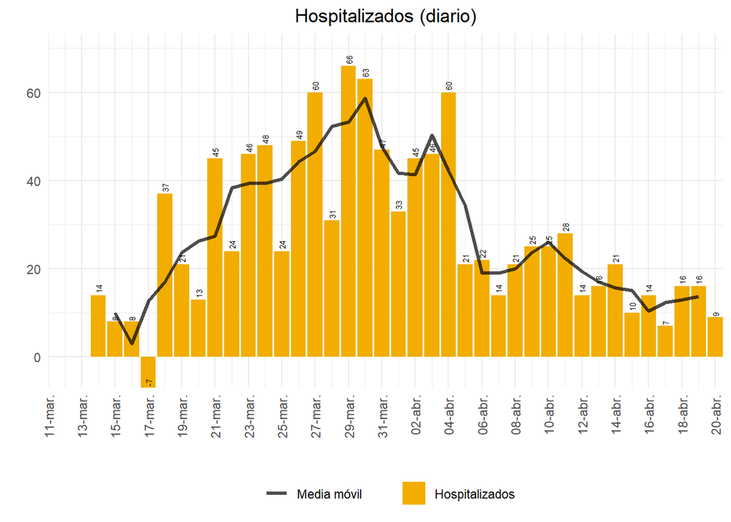

```r
h_diarios <- diario(datos, 'Hospitalizados')

evolucion_movil(h_diarios, media_movil(h_diarios, 3), 'Hospitalizados (diario)', 'Hospitalizados', '#F2AD00')
```

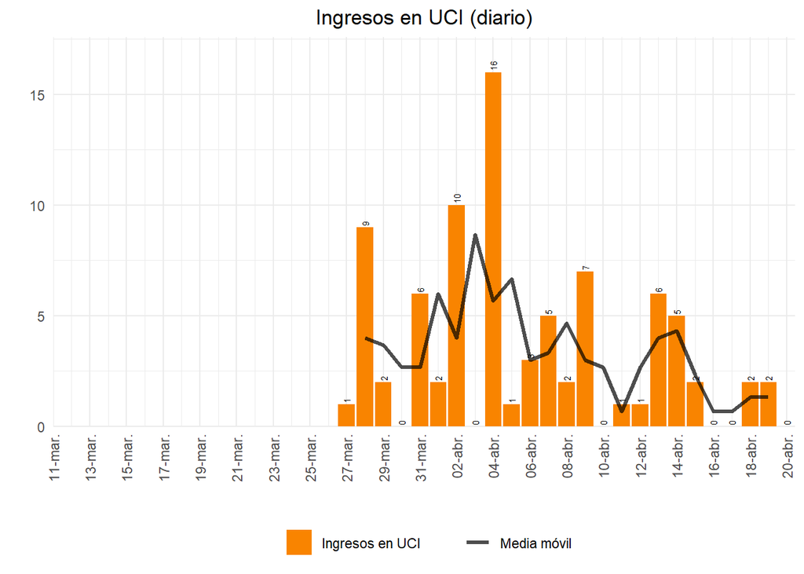

```r
u_diarios <- diario(datos, 'Total UCI')

evolucion_movil(u_diarios, media_movil(u_diarios, 3), 'Ingresos en UCI (diario)', 'Ingresos en UCI', '#F98400')
```

## 3.3 Evolución acumulada

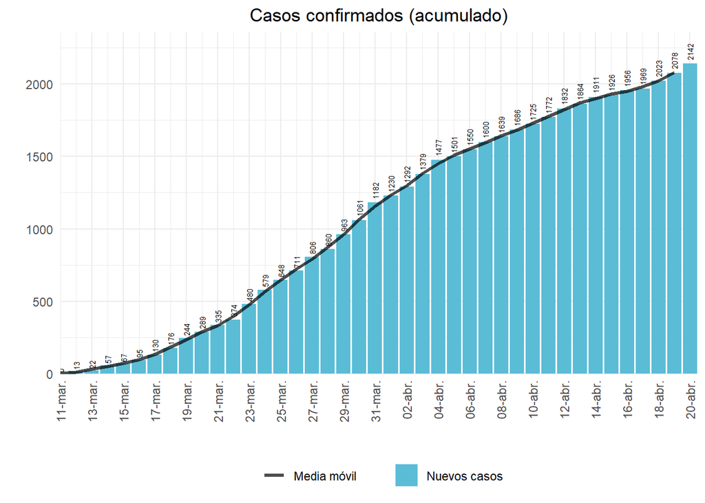

```r
d_diarios_a <- datos[which(datos$Medida == 'Confirmados'),]

evolucion_movil(d_diarios_a, media_movil(d_diarios_a, 3), 'Casos confirmados (acumulado)', 'Nuevos casos', '#5BBCD6')
```

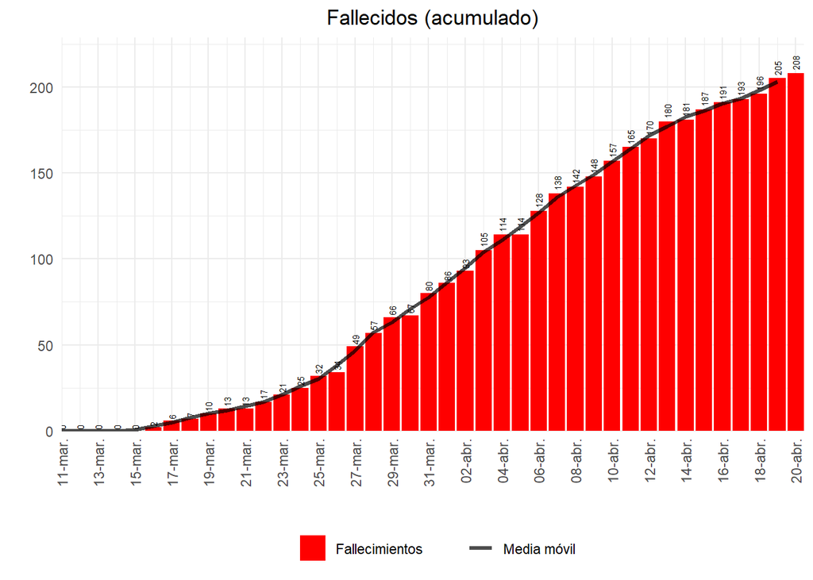

```r
f_diarios_a <- datos[which(datos$Medida == 'Fallecimientos'),]

evolucion_movil(f_diarios_a, media_movil(f_diarios_a, 3), 'Fallecidos (acumulado)', 'Fallecimientos', '#FF0000')
```

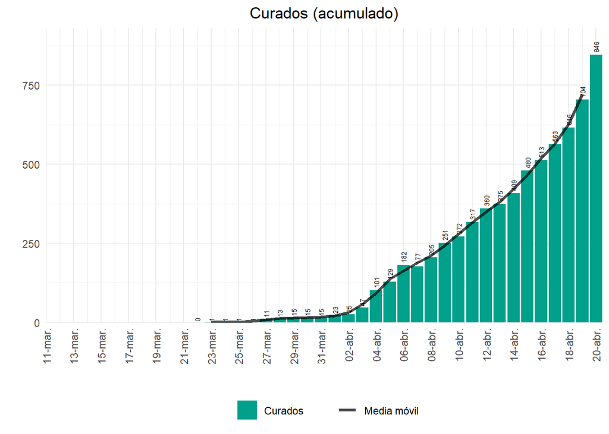

```r
c_diarios_a <- datos[which(datos$Medida == 'Curados'),]

evolucion_movil(c_diarios_a, media_movil(c_diarios_a, 3), 'Curados (acumulado)', 'Curados', '#00A08A')
```

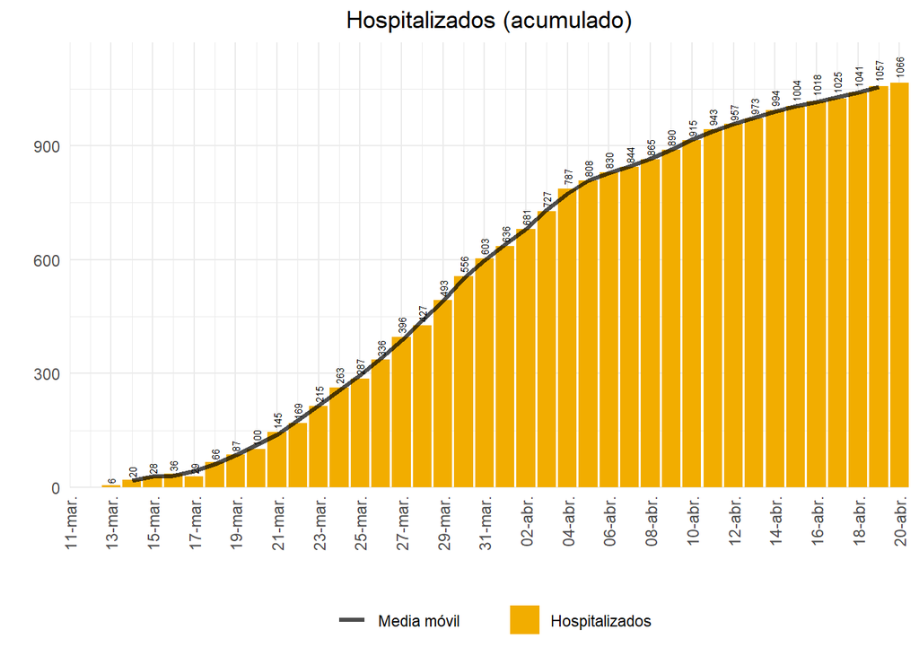

```r
h_diarios_a <- datos[which(datos$Medida == 'Hospitalizados'),]

evolucion_movil(h_diarios_a, media_movil(h_diarios_a, 3), 'Hospitalizados (acumulado)', 'Hospitalizados', '#F2AD00')
```

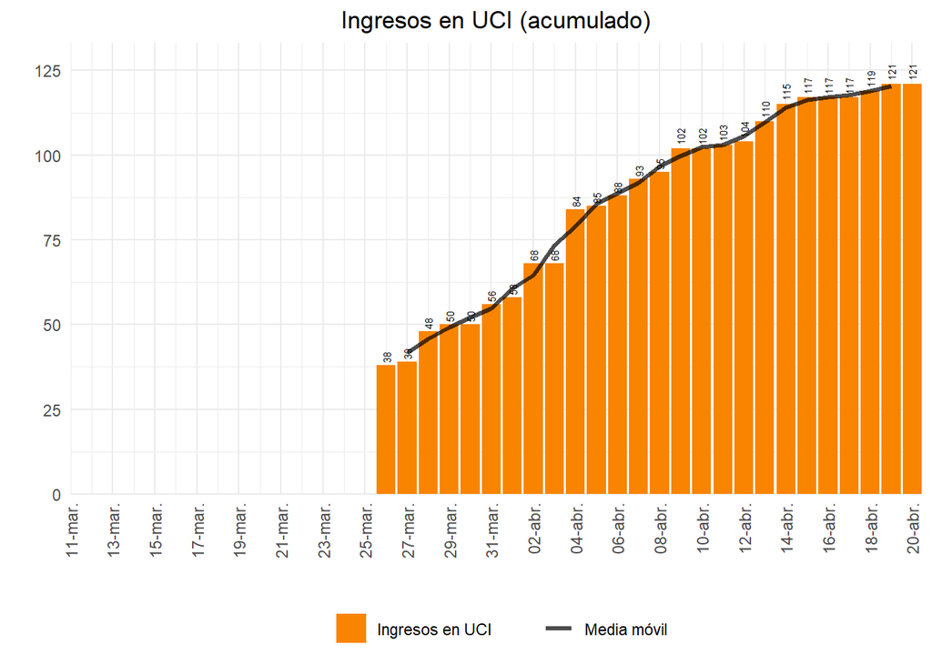

```r
u_diarios_a <- datos[which(datos$Medida == 'Total UCI'),]

evolucion_movil(u_diarios_a, media_movil(u_diarios_a, 3), 'Ingresos en UCI (acumulado)', 'Ingresos en UCI', '#F98400')
```

## 3.4 Ratios de crecimiento

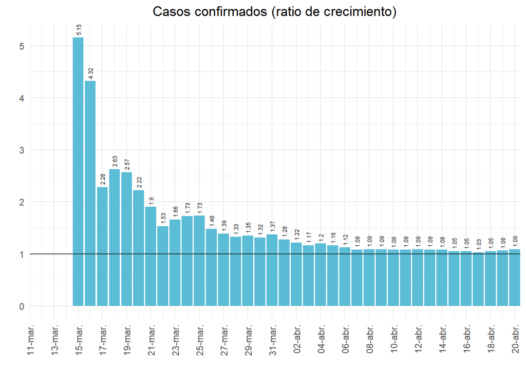

```r
d_diarios_r <- ratio_crec(datos[which(datos$Medida == 'Confirmados'),], 4)

evolucion(d_diarios_r, 'Casos confirmados (ratio de crecimiento)', '#5BBCD6')
```

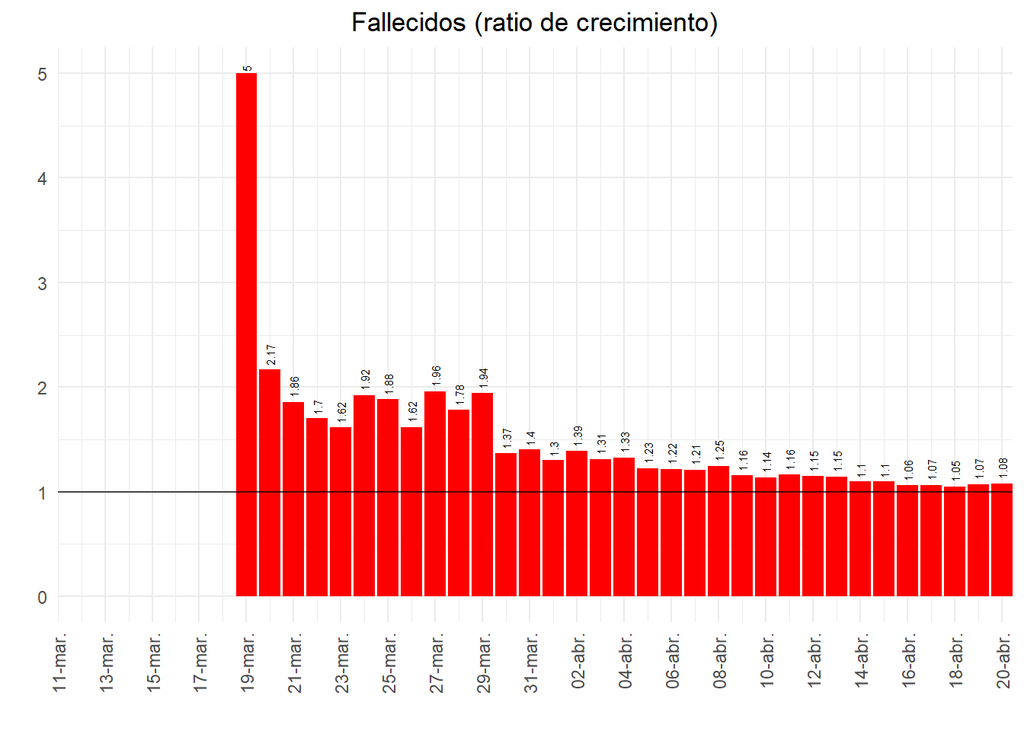

```r
f_diarios_r <- ratio_crec(datos[which(datos$Medida == 'Fallecimientos'),], 4)

evolucion(f_diarios_r, 'Fallecidos (ratio de crecimiento)', '#FF0000')
```

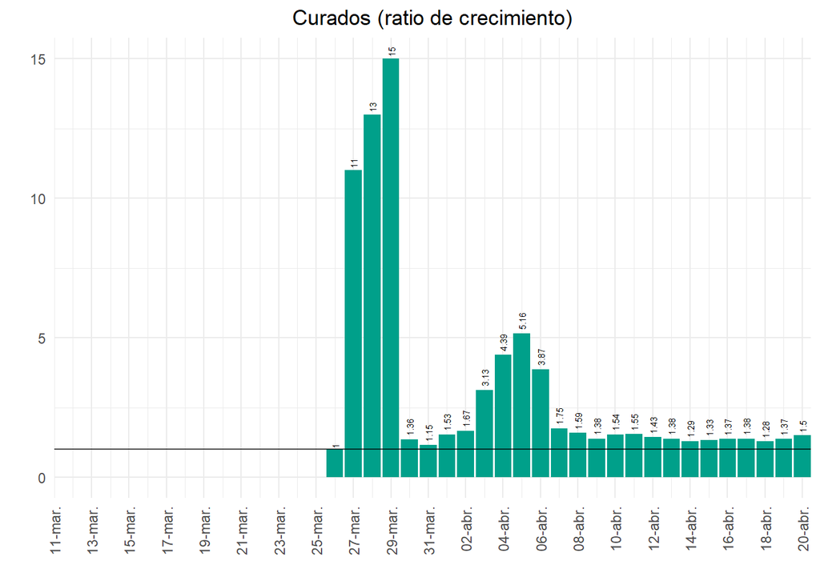

```r
c_diarios_r <- ratio_crec(datos[which(datos$Medida == 'Curados'),], 4)

evolucion(c_diarios_r, 'Curados (ratio de crecimiento)', '#00A08A')
```

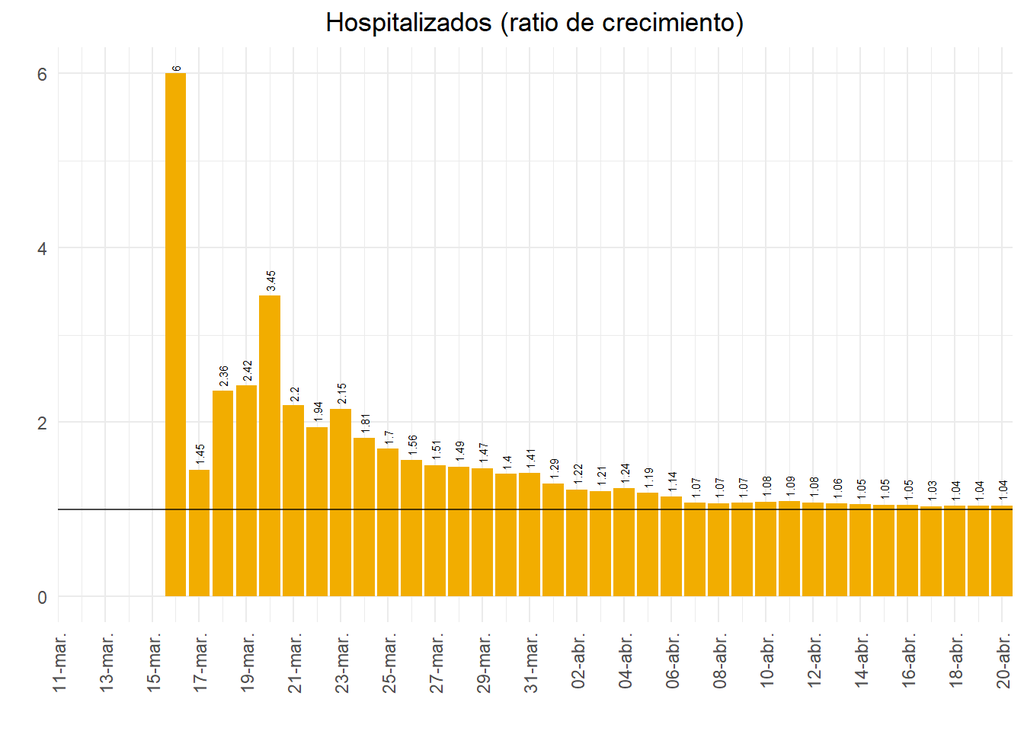

```r
h_diarios_r <- ratio_crec(datos[which(datos$Medida == 'Hospitalizados'),], 4)

evolucion(h_diarios_r, 'Hospitalizados (ratio de crecimiento)', '#F2AD00')
```

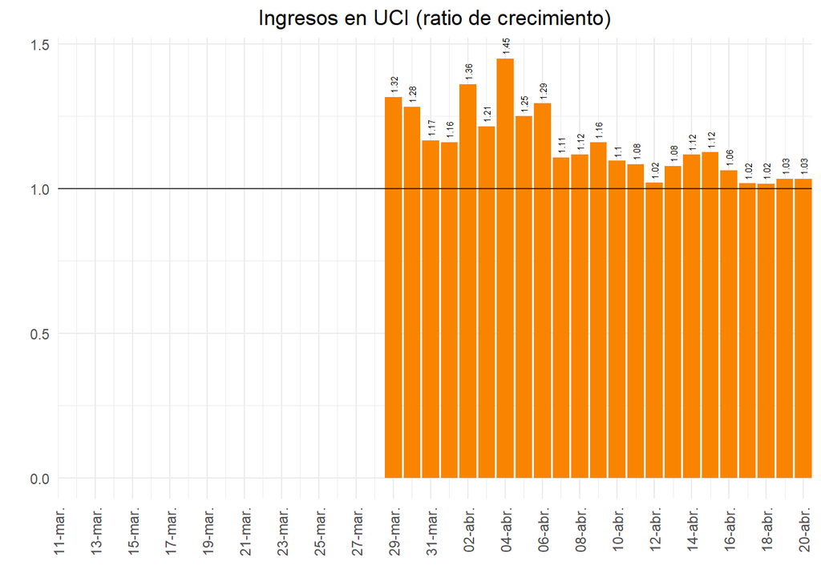

```r
u_diarios_r <- ratio_crec(datos[which(datos$Medida == 'Total UCI'),], 4)

evolucion(u_diarios_r, 'Ingresos en UCI (ratio de crecimiento)', '#F98400')
```

## 3.5 Ratios de curados

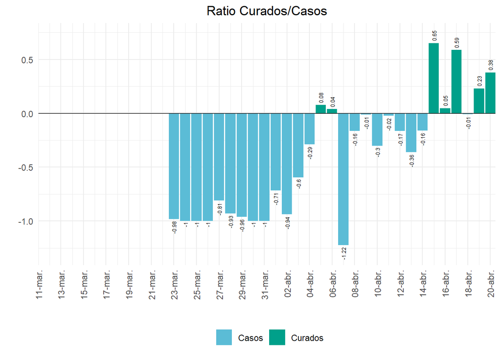

```r
ratios(c_diarios, d_diarios, 'Casos', '#5BBCD6')
```

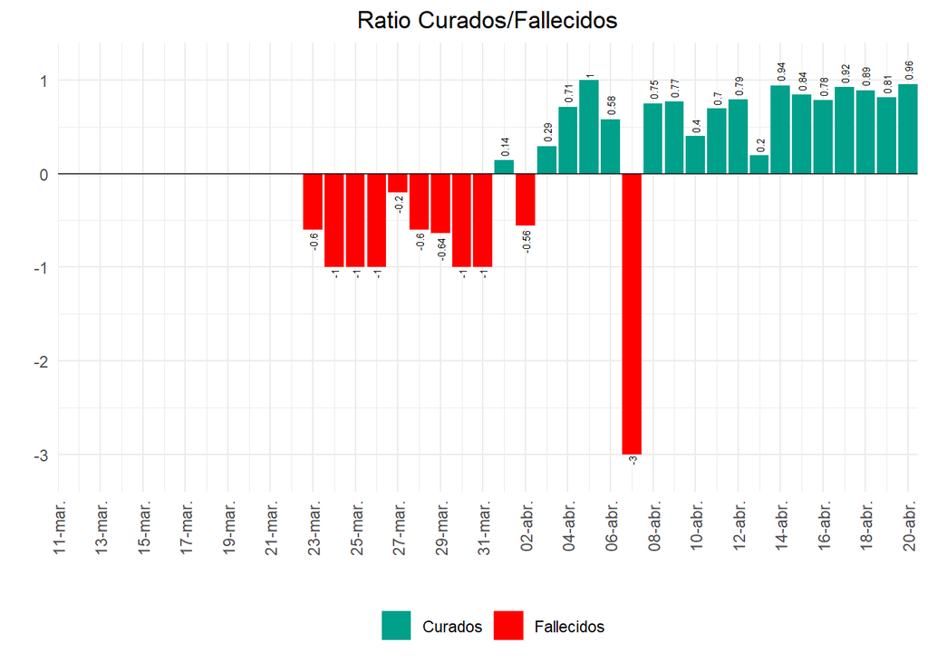

```r
ratios(c_diarios, f_diarios, 'Fallecidos', '#FF0000')
```

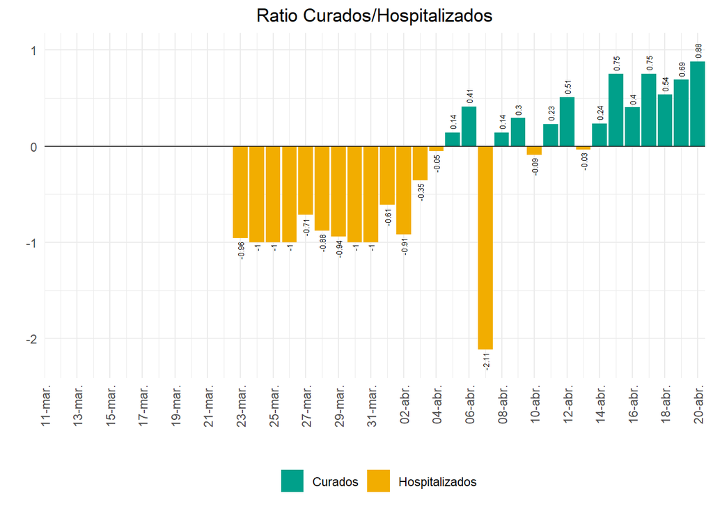

```r
ratios(c_diarios, h_diarios, 'Hospitalizados', '#F2AD00')
```

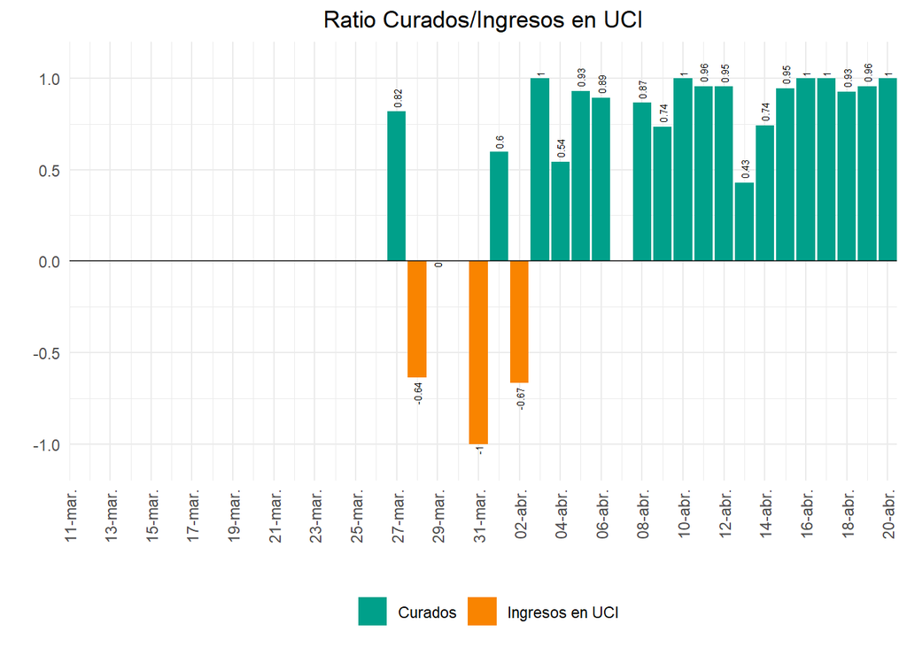

```r
ratios(c_diarios, u_diarios, 'Ingresos en UCI', '#F98400')
```

# 4 Agradecimientos

Los colores empleados en las gráficas proceden del paquete `wesanderson`.